# Risk Factor Analysis

## Outcome Variable

**Outcome Variable:** wasted

## Predictor Variables

**Intervention Variable:** birthwt

**Adjustment Set:**

- arm
- sex
- W_mage
- meducyrs
- feducyrs
- vagbrth
- single
- brthmon
- W_parity
- delta_W_mage
- delta_meducyrs
- delta_feducyrs
- delta_vagbrth
- delta_single
- delta_brthmon
- delta_W_parity

## Stratifying Variables

The analysis was stratified on these variable(s):

- agecat
- studyid
- country

## Data Summary

| agecat | studyid | country | birthwt | wasted | n_cell | n |
| --- | --- | --- | --- | --- | --- | --- |
| Birth | CMC-V-BCS-2002 | INDIA | Normal or high birthweight | 0 | 71 | 86 |
| Birth | CMC-V-BCS-2002 | INDIA | Normal or high birthweight | 1 | 5 | 86 |
| Birth | CMC-V-BCS-2002 | INDIA | Low birthweight | 0 | 4 | 86 |
| Birth | CMC-V-BCS-2002 | INDIA | Low birthweight | 1 | 6 | 86 |
| Birth | CMIN | BANGLADESH | Normal or high birthweight | 0 | 13 | 19 |
| Birth | CMIN | BANGLADESH | Normal or high birthweight | 1 | 1 | 19 |
| Birth | CMIN | BANGLADESH | Low birthweight | 0 | 2 | 19 |
| Birth | CMIN | BANGLADESH | Low birthweight | 1 | 3 | 19 |
| Birth | COHORTS | GUATEMALA | Normal or high birthweight | 0 | 540 | 756 |
| Birth | COHORTS | GUATEMALA | Normal or high birthweight | 1 | 162 | 756 |
| Birth | COHORTS | GUATEMALA | Low birthweight | 0 | 24 | 756 |
| Birth | COHORTS | GUATEMALA | Low birthweight | 1 | 30 | 756 |
| Birth | COHORTS | INDIA | Normal or high birthweight | 0 | 4632 | 6193 |
| Birth | COHORTS | INDIA | Normal or high birthweight | 1 | 546 | 6193 |
| Birth | COHORTS | INDIA | Low birthweight | 0 | 465 | 6193 |
| Birth | COHORTS | INDIA | Low birthweight | 1 | 550 | 6193 |
| Birth | COHORTS | PHILIPPINES | Normal or high birthweight | 0 | 2371 | 2899 |
| Birth | COHORTS | PHILIPPINES | Normal or high birthweight | 1 | 317 | 2899 |
| Birth | COHORTS | PHILIPPINES | Low birthweight | 0 | 77 | 2899 |
| Birth | COHORTS | PHILIPPINES | Low birthweight | 1 | 134 | 2899 |
| Birth | CONTENT | PERU | Normal or high birthweight | 0 | 2 | 2 |
| Birth | CONTENT | PERU | Normal or high birthweight | 1 | 0 | 2 |
| Birth | CONTENT | PERU | Low birthweight | 0 | 0 | 2 |
| Birth | CONTENT | PERU | Low birthweight | 1 | 0 | 2 |
| Birth | EE | PAKISTAN | Normal or high birthweight | 0 | 127 | 177 |
| Birth | EE | PAKISTAN | Normal or high birthweight | 1 | 11 | 177 |
| Birth | EE | PAKISTAN | Low birthweight | 0 | 28 | 177 |
| Birth | EE | PAKISTAN | Low birthweight | 1 | 11 | 177 |
| Birth | GMS-Nepal | NEPAL | Normal or high birthweight | 0 | 423 | 641 |
| Birth | GMS-Nepal | NEPAL | Normal or high birthweight | 1 | 49 | 641 |

[output cut: 282 more lines]

The following strata were considered:

- agecat: 24 months, studyid: CMC-V-BCS-2002, country: INDIA
- agecat: 24 months, studyid: CMIN, country: BANGLADESH
- agecat: 24 months, studyid: COHORTS, country: GUATEMALA
- agecat: 24 months, studyid: COHORTS, country: INDIA
- agecat: 24 months, studyid: COHORTS, country: PHILIPPINES
- agecat: 24 months, studyid: CONTENT, country: PERU
- agecat: 24 months, studyid: EE, country: PAKISTAN
- agecat: 24 months, studyid: GMS-Nepal, country: NEPAL
- agecat: 24 months, studyid: IRC, country: INDIA
- agecat: 24 months, studyid: JiVitA-3, country: BANGLADESH
- agecat: 24 months, studyid: JiVitA-4, country: BANGLADESH
- agecat: 24 months, studyid: Keneba, country: GAMBIA
- agecat: 24 months, studyid: MAL-ED, country: BANGLADESH
- agecat: 24 months, studyid: MAL-ED, country: BRAZIL
- agecat: 24 months, studyid: MAL-ED, country: INDIA
- agecat: 24 months, studyid: MAL-ED, country: NEPAL
- agecat: 24 months, studyid: MAL-ED, country: PERU
- agecat: 24 months, studyid: MAL-ED, country: SOUTH AFRICA
- agecat: 24 months, studyid: MAL-ED, country: TANZANIA, UNITED REPUBLIC OF
- agecat: 24 months, studyid: NIH-Birth, country: BANGLADESH
- agecat: 24 months, studyid: NIH-Crypto, country: BANGLADESH
- agecat: 24 months, studyid: PROBIT, country: BELARUS
- agecat: 24 months, studyid: PROVIDE, country: BANGLADESH
- agecat: 24 months, studyid: TanzaniaChild2, country: TANZANIA, UNITED REPUBLIC OF
- agecat: 24 months, studyid: ZVITAMBO, country: ZIMBABWE
- agecat: 6 months, studyid: CMC-V-BCS-2002, country: INDIA
- agecat: 6 months, studyid: CMIN, country: BANGLADESH
- agecat: 6 months, studyid: COHORTS, country: GUATEMALA
- agecat: 6 months, studyid: COHORTS, country: INDIA
- agecat: 6 months, studyid: COHORTS, country: PHILIPPINES
- agecat: 6 months, studyid: CONTENT, country: PERU
- agecat: 6 months, studyid: EE, country: PAKISTAN
- agecat: 6 months, studyid: GMS-Nepal, country: NEPAL
- agecat: 6 months, studyid: IRC, country: INDIA
- agecat: 6 months, studyid: JiVitA-3, country: BANGLADESH
- agecat: 6 months, studyid: JiVitA-4, country: BANGLADESH
- agecat: 6 months, studyid: Keneba, country: GAMBIA
- agecat: 6 months, studyid: MAL-ED, country: BANGLADESH
- agecat: 6 months, studyid: MAL-ED, country: BRAZIL
- agecat: 6 months, studyid: MAL-ED, country: INDIA
- agecat: 6 months, studyid: MAL-ED, country: NEPAL
- agecat: 6 months, studyid: MAL-ED, country: PERU
- agecat: 6 months, studyid: MAL-ED, country: SOUTH AFRICA
- agecat: 6 months, studyid: MAL-ED, country: TANZANIA, UNITED REPUBLIC OF
- agecat: 6 months, studyid: NIH-Birth, country: BANGLADESH
- agecat: 6 months, studyid: NIH-Crypto, country: BANGLADESH
- agecat: 6 months, studyid: PROBIT, country: BELARUS
- agecat: 6 months, studyid: PROVIDE, country: BANGLADESH
- agecat: 6 months, studyid: ResPak, country: PAKISTAN
- agecat: 6 months, studyid: SAS-CompFeed, country: INDIA
- agecat: 6 months, studyid: TanzaniaChild2, country: TANZANIA, UNITED REPUBLIC OF
- agecat: 6 months, studyid: ZVITAMBO, country: ZIMBABWE
- agecat: Birth, studyid: CMC-V-BCS-2002, country: INDIA
- agecat: Birth, studyid: CMIN, country: BANGLADESH
- agecat: Birth, studyid: COHORTS, country: GUATEMALA
- agecat: Birth, studyid: COHORTS, country: INDIA
- agecat: Birth, studyid: COHORTS, country: PHILIPPINES
- agecat: Birth, studyid: CONTENT, country: PERU
- agecat: Birth, studyid: EE, country: PAKISTAN
- agecat: Birth, studyid: GMS-Nepal, country: NEPAL
- agecat: Birth, studyid: IRC, country: INDIA
- agecat: Birth, studyid: JiVitA-3, country: BANGLADESH
- agecat: Birth, studyid: JiVitA-4, country: BANGLADESH
- agecat: Birth, studyid: Keneba, country: GAMBIA
- agecat: Birth, studyid: MAL-ED, country: BANGLADESH
- agecat: Birth, studyid: MAL-ED, country: BRAZIL
- agecat: Birth, studyid: MAL-ED, country: INDIA
- agecat: Birth, studyid: MAL-ED, country: NEPAL
- agecat: Birth, studyid: MAL-ED, country: PERU
- agecat: Birth, studyid: MAL-ED, country: SOUTH AFRICA
- agecat: Birth, studyid: MAL-ED, country: TANZANIA, UNITED REPUBLIC OF
- agecat: Birth, studyid: NIH-Birth, country: BANGLADESH
- agecat: Birth, studyid: NIH-Crypto, country: BANGLADESH
- agecat: Birth, studyid: PROBIT, country: BELARUS
- agecat: Birth, studyid: PROVIDE, country: BANGLADESH
- agecat: Birth, studyid: ResPak, country: PAKISTAN
- agecat: Birth, studyid: SAS-CompFeed, country: INDIA
- agecat: Birth, studyid: ZVITAMBO, country: ZIMBABWE

### Dropped Strata

Some strata were dropped due to rare outcomes:

- agecat: Birth, studyid: CMC-V-BCS-2002, country: INDIA
- agecat: Birth, studyid: CMIN, country: BANGLADESH
- agecat: Birth, studyid: CONTENT, country: PERU
- agecat: Birth, studyid: MAL-ED, country: BRAZIL
- agecat: Birth, studyid: MAL-ED, country: INDIA
- agecat: Birth, studyid: MAL-ED, country: NEPAL
- agecat: Birth, studyid: MAL-ED, country: PERU
- agecat: Birth, studyid: MAL-ED, country: SOUTH AFRICA
- agecat: Birth, studyid: MAL-ED, country: TANZANIA, UNITED REPUBLIC OF
- agecat: Birth, studyid: PROBIT, country: BELARUS
- agecat: Birth, studyid: ResPak, country: PAKISTAN
- agecat: 6 months, studyid: CMIN, country: BANGLADESH
- agecat: 6 months, studyid: COHORTS, country: GUATEMALA
- agecat: 6 months, studyid: CONTENT, country: PERU
- agecat: 6 months, studyid: MAL-ED, country: BANGLADESH
- agecat: 6 months, studyid: MAL-ED, country: BRAZIL
- agecat: 6 months, studyid: MAL-ED, country: INDIA
- agecat: 6 months, studyid: MAL-ED, country: NEPAL
- agecat: 6 months, studyid: MAL-ED, country: PERU
- agecat: 6 months, studyid: MAL-ED, country: SOUTH AFRICA
- agecat: 6 months, studyid: MAL-ED, country: TANZANIA, UNITED REPUBLIC OF
- agecat: 6 months, studyid: PROBIT, country: BELARUS
- agecat: 6 months, studyid: ResPak, country: PAKISTAN
- agecat: 6 months, studyid: TanzaniaChild2, country: TANZANIA, UNITED REPUBLIC OF
- agecat: 24 months, studyid: CMIN, country: BANGLADESH
- agecat: 24 months, studyid: CONTENT, country: PERU
- agecat: 24 months, studyid: MAL-ED, country: BANGLADESH
- agecat: 24 months, studyid: MAL-ED, country: BRAZIL
- agecat: 24 months, studyid: MAL-ED, country: NEPAL
- agecat: 24 months, studyid: MAL-ED, country: PERU
- agecat: 24 months, studyid: MAL-ED, country: SOUTH AFRICA
- agecat: 24 months, studyid: MAL-ED, country: TANZANIA, UNITED REPUBLIC OF
- agecat: 24 months, studyid: PROBIT, country: BELARUS
- agecat: 24 months, studyid: TanzaniaChild2, country: TANZANIA, UNITED REPUBLIC OF

## Methods Detail

We’re interested in the causal parameters $E[Y_a]$ for all values of $a \in \mathcal{A}$. These parameters represent the mean outcome if, possibly contrary to fact, we intervened to set all units to have $A=a$. Under the randomization and positivity assumptions, these are identified by the statistical parameters $\psi_a=E_W[E_{Y|A,W}(Y|A=a,W)]$. In addition, we’re interested in the mean of $Y$, $E[Y]$ under no intervention (the observed mean). We will estimate these parameters by using SuperLearner to fit the relevant likelihood factors – $E_{Y|A,W}(Y|A=a,W)$ and $p(A=a|W)$, and then updating our likelihood fit using a joint TMLE.

For unadjusted analyses ($W=\{\}$), initial likelihoods were estimated using Lrnr_glm to estimate the simple $E(Y|A)$ and Lrnr_mean to estimate $p(A)$. For adjusted analyses, a small library containing Lrnr_glmnet, Lrnr_xgboost, and Lrnr_mean was used.

Having estimated these parameters, we will then use the delta method to estimate relative risks and attributable risks relative to a prespecified baseline level of $A$.

# Results Detail

## Results Plots

[figure not shown]

[figure not shown]

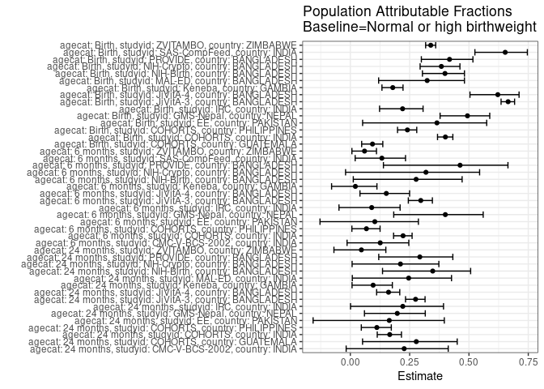

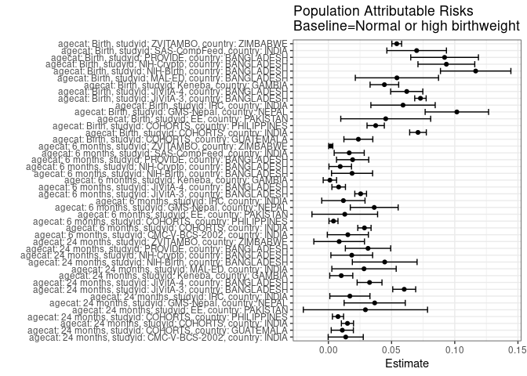

## Results Table

### Parameter: TSM

| agecat | studyid | country | intervention_level | baseline_level | estimate | ci_lower | ci_upper |
| --- | --- | --- | --- | --- | --- | --- | --- |
| Birth | COHORTS | GUATEMALA | Normal or high birthweight | NA | 0.2302529 | 0.1990653 | 0.2614405 |
| Birth | COHORTS | GUATEMALA | Low birthweight | NA | 0.5944651 | 0.4659522 | 0.7229779 |
| Birth | COHORTS | INDIA | Normal or high birthweight | NA | 0.1060711 | 0.0976640 | 0.1144782 |
| Birth | COHORTS | INDIA | Low birthweight | NA | 0.5401384 | 0.5091615 | 0.5711153 |
| Birth | COHORTS | PHILIPPINES | Normal or high birthweight | NA | 0.1181582 | 0.1059429 | 0.1303736 |
| Birth | COHORTS | PHILIPPINES | Low birthweight | NA | 0.6378997 | 0.5729599 | 0.7028395 |
| Birth | EE | PAKISTAN | Normal or high birthweight | NA | 0.0789309 | 0.0336533 | 0.1242084 |
| Birth | EE | PAKISTAN | Low birthweight | NA | 0.2257646 | 0.1005413 | 0.3509879 |
| Birth | GMS-Nepal | NEPAL | Normal or high birthweight | NA | 0.1042658 | 0.0763690 | 0.1321627 |
| Birth | GMS-Nepal | NEPAL | Low birthweight | NA | 0.4912492 | 0.4140788 | 0.5684196 |
| Birth | IRC | INDIA | Normal or high birthweight | NA | 0.2091485 | 0.1626807 | 0.2556163 |
| Birth | IRC | INDIA | Low birthweight | NA | 0.6272885 | 0.4865205 | 0.7680566 |
| Birth | JiVitA-3 | BANGLADESH | Normal or high birthweight | NA | 0.0366879 | 0.0330687 | 0.0403070 |
| Birth | JiVitA-3 | BANGLADESH | Low birthweight | NA | 0.2771939 | 0.2639759 | 0.2904119 |
| Birth | JiVitA-4 | BANGLADESH | Normal or high birthweight | NA | 0.0377444 | 0.0251708 | 0.0503180 |
| Birth | JiVitA-4 | BANGLADESH | Low birthweight | NA | 0.2737151 | 0.2309923 | 0.3164380 |
| Birth | Keneba | GAMBIA | Normal or high birthweight | NA | 0.2034723 | 0.1813264 | 0.2256181 |
| Birth | Keneba | GAMBIA | Low birthweight | NA | 0.5403869 | 0.4695117 | 0.6112622 |
| Birth | MAL-ED | BANGLADESH | Normal or high birthweight | NA | 0.1132119 | 0.0663504 | 0.1600734 |
| Birth | MAL-ED | BANGLADESH | Low birthweight | NA | 0.4559365 | 0.2897677 | 0.6221052 |
| Birth | NIH-Birth | BANGLADESH | Normal or high birthweight | NA | 0.1756201 | 0.1391720 | 0.2120681 |
| Birth | NIH-Birth | BANGLADESH | Low birthweight | NA | 0.5783565 | 0.5024313 | 0.6542816 |
| Birth | NIH-Crypto | BANGLADESH | Normal or high birthweight | NA | 0.1499230 | 0.1201626 | 0.1796834 |
| Birth | NIH-Crypto | BANGLADESH | Low birthweight | NA | 0.5818420 | 0.5001851 | 0.6634989 |
| Birth | PROVIDE | BANGLADESH | Normal or high birthweight | NA | 0.1279794 | 0.0951967 | 0.1607621 |
| Birth | PROVIDE | BANGLADESH | Low birthweight | NA | 0.5037203 | 0.4123612 | 0.5950795 |
| Birth | SAS-CompFeed | INDIA | Normal or high birthweight | NA | 0.0371445 | 0.0215508 | 0.0527381 |
| Birth | SAS-CompFeed | INDIA | Low birthweight | NA | 0.3777103 | 0.3069024 | 0.4485182 |
| Birth | ZVITAMBO | ZIMBABWE | Normal or high birthweight | NA | 0.1054750 | 0.0998899 | 0.1110601 |
| Birth | ZVITAMBO | ZIMBABWE | Low birthweight | NA | 0.6376675 | 0.6114973 | 0.6638377 |

[output cut: 58 more lines]

### Parameter: E(Y)

| agecat | studyid | country | intervention_level | baseline_level | estimate | ci_lower | ci_upper |
| --- | --- | --- | --- | --- | --- | --- | --- |
| Birth | COHORTS | GUATEMALA | NA | NA | 0.2539683 | 0.2229196 | 0.2850169 |
| Birth | COHORTS | INDIA | NA | NA | 0.1769740 | 0.1674681 | 0.1864799 |
| Birth | COHORTS | PHILIPPINES | NA | NA | 0.1555709 | 0.1423748 | 0.1687670 |
| Birth | EE | PAKISTAN | NA | NA | 0.1242938 | 0.0755526 | 0.1730349 |
| Birth | GMS-Nepal | NEPAL | NA | NA | 0.2059282 | 0.1745993 | 0.2372572 |
| Birth | IRC | INDIA | NA | NA | 0.2682216 | 0.2212677 | 0.3151755 |
| Birth | JiVitA-3 | BANGLADESH | NA | NA | 0.1095259 | 0.1044047 | 0.1146471 |
| Birth | JiVitA-4 | BANGLADESH | NA | NA | 0.0997496 | 0.0843744 | 0.1151247 |
| Birth | Keneba | GAMBIA | NA | NA | 0.2477816 | 0.2256667 | 0.2698964 |
| Birth | MAL-ED | BANGLADESH | NA | NA | 0.1674419 | 0.1174176 | 0.2174661 |
| Birth | NIH-Birth | BANGLADESH | NA | NA | 0.2921739 | 0.2549711 | 0.3293768 |
| Birth | NIH-Crypto | BANGLADESH | NA | NA | 0.2432815 | 0.2116319 | 0.2749310 |
| Birth | PROVIDE | BANGLADESH | NA | NA | 0.2199248 | 0.1846953 | 0.2551543 |
| Birth | SAS-CompFeed | INDIA | NA | NA | 0.1069810 | 0.0760961 | 0.1378659 |
| Birth | ZVITAMBO | ZIMBABWE | NA | NA | 0.1595572 | 0.1532418 | 0.1658725 |
| 6 months | CMC-V-BCS-2002 | INDIA | NA | NA | 0.1222222 | 0.0883403 | 0.1561042 |
| 6 months | COHORTS | INDIA | NA | NA | 0.1282790 | 0.1199892 | 0.1365687 |
| 6 months | COHORTS | PHILIPPINES | NA | NA | 0.0593093 | 0.0503382 | 0.0682804 |
| 6 months | EE | PAKISTAN | NA | NA | 0.1256684 | 0.0920293 | 0.1593076 |
| 6 months | GMS-Nepal | NEPAL | NA | NA | 0.0905861 | 0.0668565 | 0.1143158 |
| 6 months | IRC | INDIA | NA | NA | 0.1318408 | 0.0987276 | 0.1649539 |
| 6 months | JiVitA-3 | BANGLADESH | NA | NA | 0.0859979 | 0.0808738 | 0.0911219 |
| 6 months | JiVitA-4 | BANGLADESH | NA | NA | 0.0536465 | 0.0439582 | 0.0633347 |
| 6 months | Keneba | GAMBIA | NA | NA | 0.0554723 | 0.0431843 | 0.0677602 |
| 6 months | NIH-Birth | BANGLADESH | NA | NA | 0.0675676 | 0.0459314 | 0.0892038 |
| 6 months | NIH-Crypto | BANGLADESH | NA | NA | 0.0293706 | 0.0169860 | 0.0417552 |
| 6 months | PROVIDE | BANGLADESH | NA | NA | 0.0414594 | 0.0255348 | 0.0573839 |
| 6 months | SAS-CompFeed | INDIA | NA | NA | 0.1238671 | 0.0990601 | 0.1486741 |
| 6 months | ZVITAMBO | ZIMBABWE | NA | NA | 0.0311578 | 0.0274581 | 0.0348575 |
| 24 months | CMC-V-BCS-2002 | INDIA | NA | NA | 0.0604396 | 0.0359254 | 0.0849538 |
| 24 months | COHORTS | GUATEMALA | NA | NA | 0.0395738 | 0.0246551 | 0.0544926 |
| 24 months | COHORTS | INDIA | NA | NA | 0.0908525 | 0.0827390 | 0.0989661 |
| 24 months | COHORTS | PHILIPPINES | NA | NA | 0.0680498 | 0.0579935 | 0.0781061 |
| 24 months | EE | PAKISTAN | NA | NA | 0.1785714 | 0.1204842 | 0.2366587 |
| 24 months | GMS-Nepal | NEPAL | NA | NA | 0.1851852 | 0.1506144 | 0.2197560 |
| 24 months | IRC | INDIA | NA | NA | 0.0769231 | 0.0508746 | 0.1029716 |
| 24 months | JiVitA-3 | BANGLADESH | NA | NA | 0.2182093 | 0.2074424 | 0.2289762 |
| 24 months | JiVitA-4 | BANGLADESH | NA | NA | 0.2024018 | 0.1878193 | 0.2169843 |
| 24 months | Keneba | GAMBIA | NA | NA | 0.1059603 | 0.0873965 | 0.1245240 |
| 24 months | MAL-ED | INDIA | NA | NA | 0.1146789 | 0.0722843 | 0.1570735 |
| 24 months | NIH-Birth | BANGLADESH | NA | NA | 0.1283293 | 0.0960341 | 0.1606245 |
| 24 months | NIH-Crypto | BANGLADESH | NA | NA | 0.0875486 | 0.0630907 | 0.1120065 |
| 24 months | PROVIDE | BANGLADESH | NA | NA | 0.1070812 | 0.0818727 | 0.1322897 |
| 24 months | ZVITAMBO | ZIMBABWE | NA | NA | 0.1832947 | 0.1467250 | 0.2198644 |

### Parameter: RR

| agecat | studyid | country | intervention_level | baseline_level | estimate | ci_lower | ci_upper |
| --- | --- | --- | --- | --- | --- | --- | --- |
| Birth | COHORTS | GUATEMALA | Normal or high birthweight | Normal or high birthweight | 1.000000 | 1.0000000 | 1.000000 |
| Birth | COHORTS | GUATEMALA | Low birthweight | Normal or high birthweight | 2.581792 | 2.0019000 | 3.329661 |
| Birth | COHORTS | INDIA | Normal or high birthweight | Normal or high birthweight | 1.000000 | 1.0000000 | 1.000000 |
| Birth | COHORTS | INDIA | Low birthweight | Normal or high birthweight | 5.092228 | 4.6173554 | 5.615940 |
| Birth | COHORTS | PHILIPPINES | Normal or high birthweight | Normal or high birthweight | 1.000000 | 1.0000000 | 1.000000 |
| Birth | COHORTS | PHILIPPINES | Low birthweight | Normal or high birthweight | 5.398691 | 4.6701730 | 6.240852 |
| Birth | EE | PAKISTAN | Normal or high birthweight | Normal or high birthweight | 1.000000 | 1.0000000 | 1.000000 |
| Birth | EE | PAKISTAN | Low birthweight | Normal or high birthweight | 2.860283 | 1.2837839 | 6.372738 |
| Birth | GMS-Nepal | NEPAL | Normal or high birthweight | Normal or high birthweight | 1.000000 | 1.0000000 | 1.000000 |
| Birth | GMS-Nepal | NEPAL | Low birthweight | Normal or high birthweight | 4.711506 | 3.4522795 | 6.430039 |
| Birth | IRC | INDIA | Normal or high birthweight | Normal or high birthweight | 1.000000 | 1.0000000 | 1.000000 |
| Birth | IRC | INDIA | Low birthweight | Normal or high birthweight | 2.999250 | 2.1864170 | 4.114265 |
| Birth | JiVitA-3 | BANGLADESH | Normal or high birthweight | Normal or high birthweight | 1.000000 | 1.0000000 | 1.000000 |
| Birth | JiVitA-3 | BANGLADESH | Low birthweight | Normal or high birthweight | 7.555465 | 6.7742966 | 8.426713 |
| Birth | JiVitA-4 | BANGLADESH | Normal or high birthweight | Normal or high birthweight | 1.000000 | 1.0000000 | 1.000000 |
| Birth | JiVitA-4 | BANGLADESH | Low birthweight | Normal or high birthweight | 7.251807 | 5.0384417 | 10.437493 |
| Birth | Keneba | GAMBIA | Normal or high birthweight | Normal or high birthweight | 1.000000 | 1.0000000 | 1.000000 |
| Birth | Keneba | GAMBIA | Low birthweight | Normal or high birthweight | 2.655826 | 2.2397197 | 3.149238 |
| Birth | MAL-ED | BANGLADESH | Normal or high birthweight | Normal or high birthweight | 1.000000 | 1.0000000 | 1.000000 |
| Birth | MAL-ED | BANGLADESH | Low birthweight | Normal or high birthweight | 4.027284 | 2.3197444 | 6.991724 |
| Birth | NIH-Birth | BANGLADESH | Normal or high birthweight | Normal or high birthweight | 1.000000 | 1.0000000 | 1.000000 |
| Birth | NIH-Birth | BANGLADESH | Low birthweight | Normal or high birthweight | 3.293225 | 2.5764593 | 4.209394 |
| Birth | NIH-Crypto | BANGLADESH | Normal or high birthweight | Normal or high birthweight | 1.000000 | 1.0000000 | 1.000000 |
| Birth | NIH-Crypto | BANGLADESH | Low birthweight | Normal or high birthweight | 3.880939 | 3.0420088 | 4.951230 |
| Birth | PROVIDE | BANGLADESH | Normal or high birthweight | Normal or high birthweight | 1.000000 | 1.0000000 | 1.000000 |
| Birth | PROVIDE | BANGLADESH | Low birthweight | Normal or high birthweight | 3.935950 | 2.8771725 | 5.384349 |
| Birth | SAS-CompFeed | INDIA | Normal or high birthweight | Normal or high birthweight | 1.000000 | 1.0000000 | 1.000000 |
| Birth | SAS-CompFeed | INDIA | Low birthweight | Normal or high birthweight | 10.168681 | 6.3834822 | 16.198382 |
| Birth | ZVITAMBO | ZIMBABWE | Normal or high birthweight | Normal or high birthweight | 1.000000 | 1.0000000 | 1.000000 |
| Birth | ZVITAMBO | ZIMBABWE | Low birthweight | Normal or high birthweight | 6.045673 | 5.6541270 | 6.464333 |

[output cut: 58 more lines]

### Parameter: PAR

| agecat | studyid | country | intervention_level | baseline_level | estimate | ci_lower | ci_upper |
| --- | --- | --- | --- | --- | --- | --- | --- |
| Birth | COHORTS | GUATEMALA | Normal or high birthweight | NA | 0.0237154 | 0.0122764 | 0.0351543 |
| Birth | COHORTS | INDIA | Normal or high birthweight | NA | 0.0709029 | 0.0643167 | 0.0774891 |
| Birth | COHORTS | PHILIPPINES | Normal or high birthweight | NA | 0.0374127 | 0.0305718 | 0.0442535 |
| Birth | EE | PAKISTAN | Normal or high birthweight | NA | 0.0453629 | 0.0097846 | 0.0809412 |
| Birth | GMS-Nepal | NEPAL | Normal or high birthweight | NA | 0.1016624 | 0.0765651 | 0.1267597 |
| Birth | IRC | INDIA | Normal or high birthweight | NA | 0.0590731 | 0.0336243 | 0.0845219 |
| Birth | JiVitA-3 | BANGLADESH | Normal or high birthweight | NA | 0.0728381 | 0.0683147 | 0.0773614 |
| Birth | JiVitA-4 | BANGLADESH | Normal or high birthweight | NA | 0.0620052 | 0.0492768 | 0.0747335 |
| Birth | Keneba | GAMBIA | Normal or high birthweight | NA | 0.0443093 | 0.0329942 | 0.0556244 |
| Birth | MAL-ED | BANGLADESH | Normal or high birthweight | NA | 0.0542300 | 0.0213058 | 0.0871541 |
| Birth | NIH-Birth | BANGLADESH | Normal or high birthweight | NA | 0.1165538 | 0.0886838 | 0.1444239 |
| Birth | NIH-Crypto | BANGLADESH | Normal or high birthweight | NA | 0.0933585 | 0.0708832 | 0.1158337 |
| Birth | PROVIDE | BANGLADESH | Normal or high birthweight | NA | 0.0919454 | 0.0651560 | 0.1187349 |
| Birth | SAS-CompFeed | INDIA | Normal or high birthweight | NA | 0.0698365 | 0.0462633 | 0.0934097 |
| Birth | ZVITAMBO | ZIMBABWE | Normal or high birthweight | NA | 0.0540822 | 0.0502190 | 0.0579453 |
| 6 months | CMC-V-BCS-2002 | INDIA | Normal or high birthweight | NA | 0.0153895 | -0.0008626 | 0.0316415 |
| 6 months | COHORTS | INDIA | Normal or high birthweight | NA | 0.0285130 | 0.0232593 | 0.0337668 |
| 6 months | COHORTS | PHILIPPINES | Normal or high birthweight | NA | 0.0040215 | 0.0004564 | 0.0075866 |
| 6 months | EE | PAKISTAN | Normal or high birthweight | NA | 0.0129625 | -0.0130098 | 0.0389349 |
| 6 months | GMS-Nepal | NEPAL | Normal or high birthweight | NA | 0.0362689 | 0.0173281 | 0.0552097 |
| 6 months | IRC | INDIA | Normal or high birthweight | NA | 0.0118653 | -0.0052559 | 0.0289865 |
| 6 months | JiVitA-3 | BANGLADESH | Normal or high birthweight | NA | 0.0255338 | 0.0208858 | 0.0301819 |
| 6 months | JiVitA-4 | BANGLADESH | Normal or high birthweight | NA | 0.0081314 | 0.0027713 | 0.0134914 |
| 6 months | Keneba | GAMBIA | Normal or high birthweight | NA | 0.0011745 | -0.0041248 | 0.0064738 |
| 6 months | NIH-Birth | BANGLADESH | Normal or high birthweight | NA | 0.0187372 | 0.0024811 | 0.0349933 |
| 6 months | NIH-Crypto | BANGLADESH | Normal or high birthweight | NA | 0.0093576 | 0.0004315 | 0.0182838 |
| 6 months | PROVIDE | BANGLADESH | Normal or high birthweight | NA | 0.0191764 | 0.0064332 | 0.0319195 |
| 6 months | SAS-CompFeed | INDIA | Normal or high birthweight | NA | 0.0164642 | 0.0045712 | 0.0283571 |
| 6 months | ZVITAMBO | ZIMBABWE | Normal or high birthweight | NA | 0.0018636 | 0.0002372 | 0.0034900 |
| 24 months | CMC-V-BCS-2002 | INDIA | Normal or high birthweight | NA | 0.0137106 | -0.0001707 | 0.0275919 |
| 24 months | COHORTS | GUATEMALA | Normal or high birthweight | NA | 0.0110024 | 0.0022289 | 0.0197759 |
| 24 months | COHORTS | INDIA | Normal or high birthweight | NA | 0.0150814 | 0.0102863 | 0.0198765 |
| 24 months | COHORTS | PHILIPPINES | Normal or high birthweight | NA | 0.0075998 | 0.0031739 | 0.0120257 |
| 24 months | EE | PAKISTAN | Normal or high birthweight | NA | 0.0293068 | -0.0198497 | 0.0784633 |
| 24 months | GMS-Nepal | NEPAL | Normal or high birthweight | NA | 0.0366400 | 0.0124351 | 0.0608449 |
| 24 months | IRC | INDIA | Normal or high birthweight | NA | 0.0170040 | 0.0011208 | 0.0328871 |
| 24 months | JiVitA-3 | BANGLADESH | Normal or high birthweight | NA | 0.0600018 | 0.0509298 | 0.0690737 |
| 24 months | JiVitA-4 | BANGLADESH | Normal or high birthweight | NA | 0.0325743 | 0.0227416 | 0.0424070 |
| 24 months | Keneba | GAMBIA | Normal or high birthweight | NA | 0.0101843 | 0.0010581 | 0.0193105 |
| 24 months | MAL-ED | INDIA | Normal or high birthweight | NA | 0.0281924 | 0.0027333 | 0.0536515 |
| 24 months | NIH-Birth | BANGLADESH | Normal or high birthweight | NA | 0.0445633 | 0.0189485 | 0.0701782 |
| 24 months | NIH-Crypto | BANGLADESH | Normal or high birthweight | NA | 0.0184894 | 0.0019729 | 0.0350059 |
| 24 months | PROVIDE | BANGLADESH | Normal or high birthweight | NA | 0.0313631 | 0.0134164 | 0.0493097 |
| 24 months | ZVITAMBO | ZIMBABWE | Normal or high birthweight | NA | 0.0085221 | -0.0115216 | 0.0285657 |

### Parameter: PAF

| agecat | studyid | country | intervention_level | baseline_level | estimate | ci_lower | ci_upper |
| --- | --- | --- | --- | --- | --- | --- | --- |
| Birth | COHORTS | GUATEMALA | Normal or high birthweight | NA | 0.0933792 | 0.0477472 | 0.1368245 |
| Birth | COHORTS | INDIA | Normal or high birthweight | NA | 0.4006401 | 0.3674842 | 0.4320581 |
| Birth | COHORTS | PHILIPPINES | Normal or high birthweight | NA | 0.2404863 | 0.1989285 | 0.2798882 |
| Birth | EE | PAKISTAN | Normal or high birthweight | NA | 0.3649654 | 0.0517624 | 0.5747174 |
| Birth | GMS-Nepal | NEPAL | Normal or high birthweight | NA | 0.4936787 | 0.3783512 | 0.5876108 |
| Birth | IRC | INDIA | Normal or high birthweight | NA | 0.2202398 | 0.1231877 | 0.3065495 |
| Birth | JiVitA-3 | BANGLADESH | Normal or high birthweight | NA | 0.6650303 | 0.6353171 | 0.6923226 |
| Birth | JiVitA-4 | BANGLADESH | Normal or high birthweight | NA | 0.6216084 | 0.5042445 | 0.7111878 |
| Birth | Keneba | GAMBIA | Normal or high birthweight | NA | 0.1788240 | 0.1332041 | 0.2220430 |
| Birth | MAL-ED | BANGLADESH | Normal or high birthweight | NA | 0.3238733 | 0.1192224 | 0.4809731 |
| Birth | NIH-Birth | BANGLADESH | Normal or high birthweight | NA | 0.3989194 | 0.3038522 | 0.4810040 |
| Birth | NIH-Crypto | BANGLADESH | Normal or high birthweight | NA | 0.3837467 | 0.2941372 | 0.4619803 |
| Birth | PROVIDE | BANGLADESH | Normal or high birthweight | NA | 0.4180767 | 0.2993083 | 0.5167137 |
| Birth | SAS-CompFeed | INDIA | Normal or high birthweight | NA | 0.6527936 | 0.5250189 | 0.7461957 |
| Birth | ZVITAMBO | ZIMBABWE | Normal or high birthweight | NA | 0.3389515 | 0.3173509 | 0.3598687 |
| 6 months | CMC-V-BCS-2002 | INDIA | Normal or high birthweight | NA | 0.1259139 | -0.0138553 | 0.2464146 |
| 6 months | COHORTS | INDIA | Normal or high birthweight | NA | 0.2222736 | 0.1822942 | 0.2602983 |
| 6 months | COHORTS | PHILIPPINES | Normal or high birthweight | NA | 0.0678052 | 0.0064949 | 0.1253320 |
| 6 months | EE | PAKISTAN | Normal or high birthweight | NA | 0.1031487 | -0.1278967 | 0.2868654 |
| 6 months | GMS-Nepal | NEPAL | Normal or high birthweight | NA | 0.4003805 | 0.1828913 | 0.5599807 |
| 6 months | IRC | INDIA | Normal or high birthweight | NA | 0.0899972 | -0.0479030 | 0.2097503 |
| 6 months | JiVitA-3 | BANGLADESH | Normal or high birthweight | NA | 0.2969124 | 0.2443835 | 0.3457896 |
| 6 months | JiVitA-4 | BANGLADESH | Normal or high birthweight | NA | 0.1515730 | 0.0405463 | 0.2497519 |
| 6 months | Keneba | GAMBIA | Normal or high birthweight | NA | 0.0211729 | -0.0790654 | 0.1120997 |
| 6 months | NIH-Birth | BANGLADESH | Normal or high birthweight | NA | 0.2773104 | 0.0124075 | 0.4711581 |
| 6 months | NIH-Crypto | BANGLADESH | Normal or high birthweight | NA | 0.3186056 | -0.0201190 | 0.5448587 |
| 6 months | PROVIDE | BANGLADESH | Normal or high birthweight | NA | 0.4625337 | 0.1394251 | 0.6643290 |
| 6 months | SAS-CompFeed | INDIA | Normal or high birthweight | NA | 0.1329179 | 0.0203099 | 0.2325825 |
| 6 months | ZVITAMBO | ZIMBABWE | Normal or high birthweight | NA | 0.0598118 | 0.0066100 | 0.1101643 |
| 24 months | CMC-V-BCS-2002 | INDIA | Normal or high birthweight | NA | 0.2268479 | -0.0176306 | 0.4125922 |
| 24 months | COHORTS | GUATEMALA | Normal or high birthweight | NA | 0.2780220 | 0.0514908 | 0.4504510 |
| 24 months | COHORTS | INDIA | Normal or high birthweight | NA | 0.1659987 | 0.1133909 | 0.2154850 |
| 24 months | COHORTS | PHILIPPINES | Normal or high birthweight | NA | 0.1116798 | 0.0462335 | 0.1726352 |
| 24 months | EE | PAKISTAN | Normal or high birthweight | NA | 0.1641180 | -0.1569838 | 0.3961033 |
| 24 months | GMS-Nepal | NEPAL | Normal or high birthweight | NA | 0.1978560 | 0.0595004 | 0.3158584 |
| 24 months | IRC | INDIA | Normal or high birthweight | NA | 0.2210517 | 0.0008232 | 0.3927396 |
| 24 months | JiVitA-3 | BANGLADESH | Normal or high birthweight | NA | 0.2749734 | 0.2326579 | 0.3149555 |
| 24 months | JiVitA-4 | BANGLADESH | Normal or high birthweight | NA | 0.1609387 | 0.1108098 | 0.2082415 |
| 24 months | Keneba | GAMBIA | Normal or high birthweight | NA | 0.0961146 | 0.0072160 | 0.1770528 |
| 24 months | MAL-ED | INDIA | Normal or high birthweight | NA | 0.2458378 | 0.0083077 | 0.4264748 |
| 24 months | NIH-Birth | BANGLADESH | Normal or high birthweight | NA | 0.3472576 | 0.1356365 | 0.5070678 |
| 24 months | NIH-Crypto | BANGLADESH | Normal or high birthweight | NA | 0.2111897 | 0.0074599 | 0.3731018 |
| 24 months | PROVIDE | BANGLADESH | Normal or high birthweight | NA | 0.2928906 | 0.1196697 | 0.4320272 |
| 24 months | ZVITAMBO | ZIMBABWE | Normal or high birthweight | NA | 0.0464937 | -0.0691648 | 0.1496407 |